# Impacts of Fisheries in Area 7

Meghan Roberts

2023-08-07

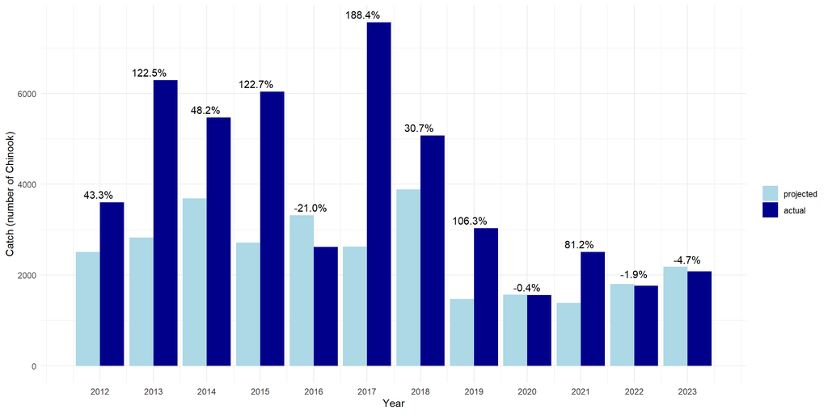

Figure 1. Actual vs. Projected Catch of Chinook Salmon in Area 7 by Year. Data for 2022 (*) is an estimated initial value from D. Dapp. The values over the bar show the percent overage. Percent overage is calculated according to the formula below.

$$\text{Percent Overage} = \frac{\text{Actual Catch} - \text{Projected
Catch}}{\text{Projected Catch}} \times 100$$

#### **SRKW Spatial Overlap**

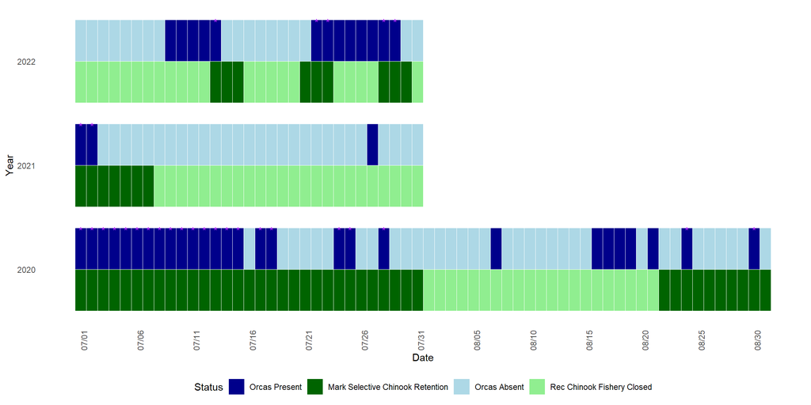

Figure 2. Chinook fishery retention in area 7 compared to SRKW presence in the region.

This figure shows when the SRKW could have overlapped with fisheries from 2020 to 2022. The top bar (blue) shows when orcas were present or absent in area 7 and the bottom bar (green) shows when Chinook retention in area 7 is open or closed. Purple stars show days where SRKW sightings occurred in inland waters and the Chinook fishery was open for retention. In area 7, the fisheries overlapped with SRKW presence 29 days of 41 days the fishery was open in 2020, 2 of 7 days in 2021 and 6 of 9 days in 2022.

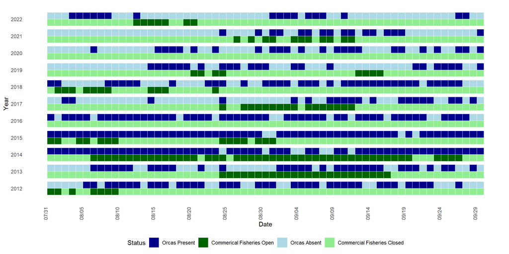

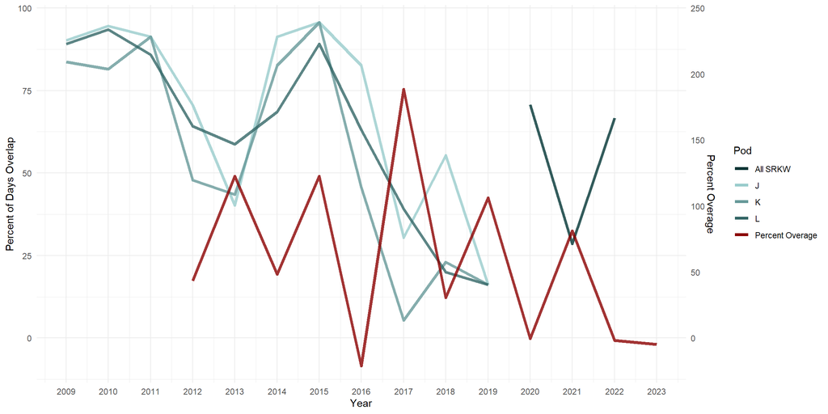

Figure 3. Maximum percentage of days that SRKW could overlap with Chinook fisheries by year and percent overage. Data for percent of days overlapped is not separated by pod after 2019.

Given the maximum amount of days that SRKW were seen in inland waters from 2009 to 2022, the percentage of days that SRKW could have overlapped with Chinook fisheries in Area 7 was calculated. From 2009 to 2019, this data is reported separately for each pod. After this, the SRKW sightings are grouped together. There is no clear trend in the percentage of days that SRKW overlap with fisheries despite the number of days for Chinook retention decreasing since 2009. In 2017 when percent overage was high, the percent of days overlap for SRKW and the fishery is lower for all pods than in previous years. Percent of days overlap is calculated according to the equation below:

$$\text{Percent of Days Overlap} = \frac{\text{# of days SRKW are sighted
in Area 7 when fisheries are open}}{\text{# of chinook retention days}}
\times 100$$

#### **SRKW Births and Deaths**

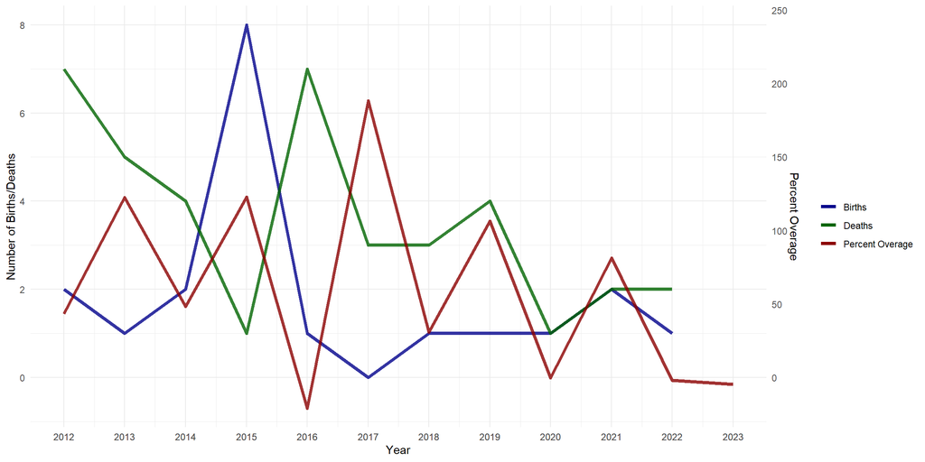

Figure 4. The number of births and deaths per year of SRKW compared to percent overage.

From 2012 to 2022, the SRKW births peaked in 2015 and dipped during 2017. Whereas deaths were highest in 2012 and 2016. Percent overage for Chinook fisheries was highest in 2017, then next highest in 2013 and 2015. None of these peaks necessarily line up with each other in a way that suggests correlation.

#### **Days Open to Chinook Retention**

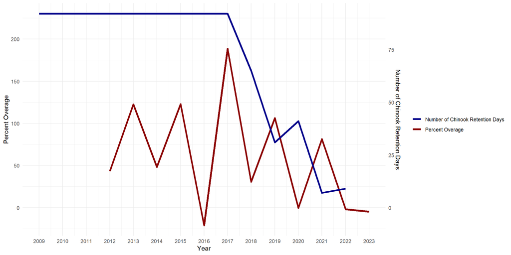

This plot shows that there is no clear pattern between the number of days open for Chinook retention in Area 7 and the percentage that the actual catch over shot the projected values by.

#### **Anglers Per Day**

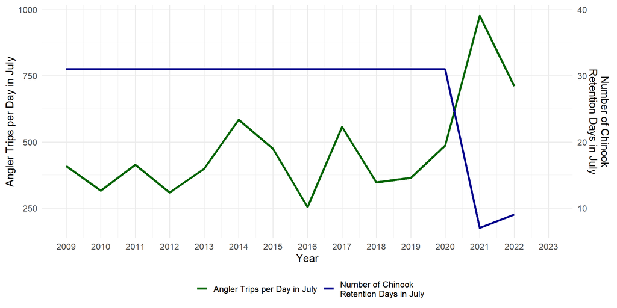

Figure 6. The number of anglers per day on days in July when Area 7 allows Chinook retention over time and number of days that the fishery is open to retention of Chinook in July by year. Values for angler trips in July for 2009-2020 are from J. Carey querying the most current CRC database.

The number of anglers per day has increased over time as the number of days that the Chinook fishery is open for retention has decreased.

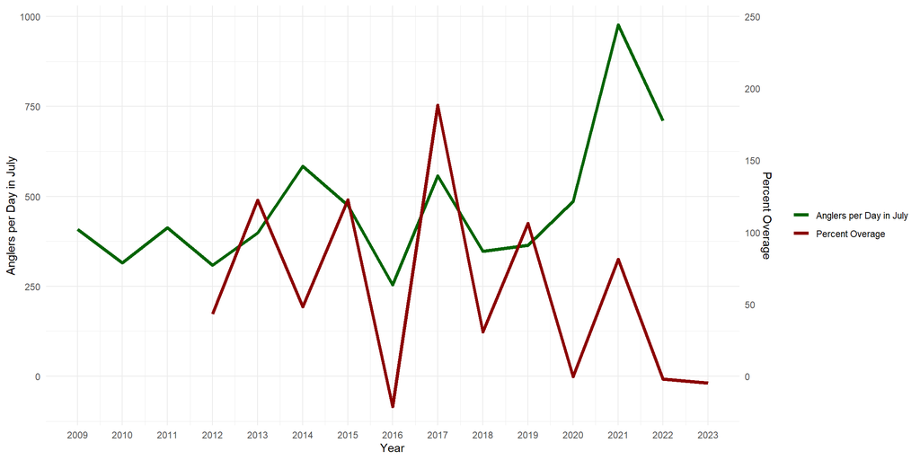

Figure 7. The number of anglers per day in July on days when Area 7 allows Chinook retention over time and percent overage by year. Values for angler trips in July for 2009-2020 are from J. Carey querying the most current CRC database.

There is no clear relationship between anglers per day and percent overage.

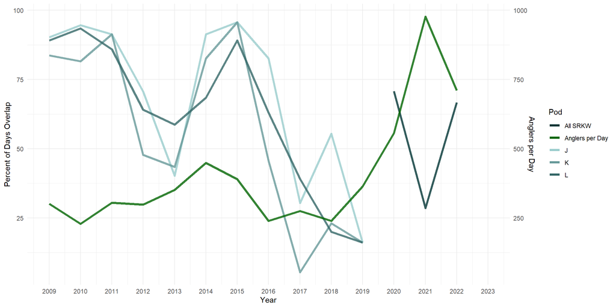

Figure 8. Maximum percentage of days that SRKW could overlap with Chinook fisheries by year and average anglers per day of Chinook retention. Data for percent of days overlapped is not separated by pod after 2019.

This plot shows how percent of days that SRKW sightings overlap with Chinook retention days. In recent years, it appears that anglers per day has increased and SRKW are overlapping with the fisheries more than 25% of the time.

#### **Fraser Chinook**

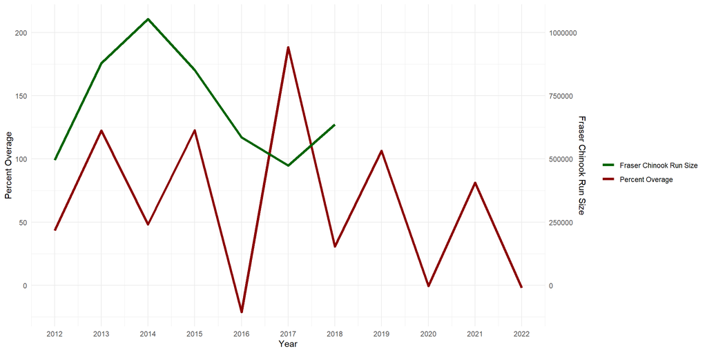

Figure 9. This plot shows the percentage that the actual catch over shot the projected values by as well as fraser abundance over time.